# Principle Component Aanalysis

## Data

The data you will be using comes from the Assistments online intelligent tutoring system (https://www.assistments.org/). It describes students working through online math problems. Each student has the following data associated with them:

- id
- prior_prob_count: How many problems a student has answered in the system prior to this session
- prior_percent_correct: The percentage of problems a student has answered correctly prior to this session
- problems_attempted: The number of problems the student has attempted in the current session
- mean_correct: The average number of correct answers a student made on their first attempt at problems in the current session
- mean_hint: The average number of hints a student asked for in the current session
- mean_attempt: The average number of attempts a student took to answer a problem in the current session
- mean_confidence: The average confidence each student has in their ability to answer the problems in the current session

## Start by uploading the data

```r
library(tidyverse)
D1 <- read_csv("Assistments-confidence.csv")
head(D1)
```

```
## # A tibble: 6 x 8
##       id prior_prob_count prior_percent_c… problems_attemp… mean_correct
##    <dbl>            <dbl>            <dbl>            <dbl>        <dbl>
## 1 172777              650            0.723                4        1
## 2 175658             1159            0.801               22        0.455
## 3 175669             1239            0.657               11        0.636
## 4 176151             1246            0.730               16        0.75
## 5 176165             1299            0.568                6        0.333
## 6 176168             1415            0.685               11        0.545
## # … with 3 more variables: mean_hint <dbl>, mean_attempt <dbl>,
## #   mean_confidence <dbl>
```

## Create a correlation matrix of the relationships between the variables, including correlation coefficients for each pair of variables/features.

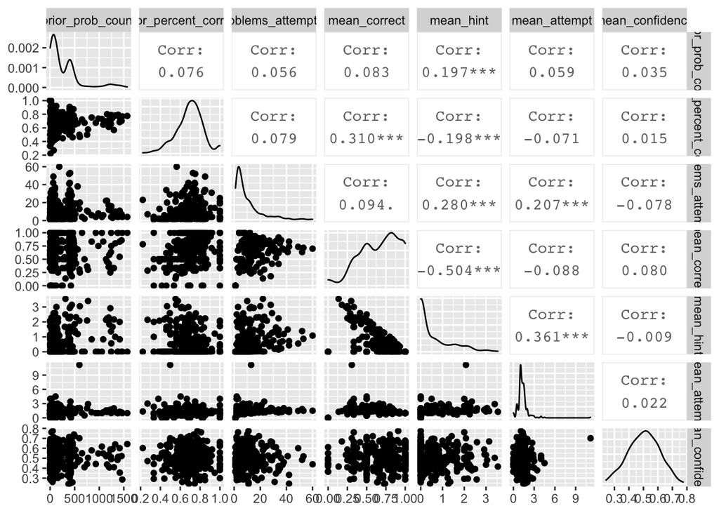

```r
#You can install the corrplot package to plot some pretty correlation matrices (sometimes called correlograms)

library(GGally)
ggpairs(D1, 2:8, progress = FALSE)
```

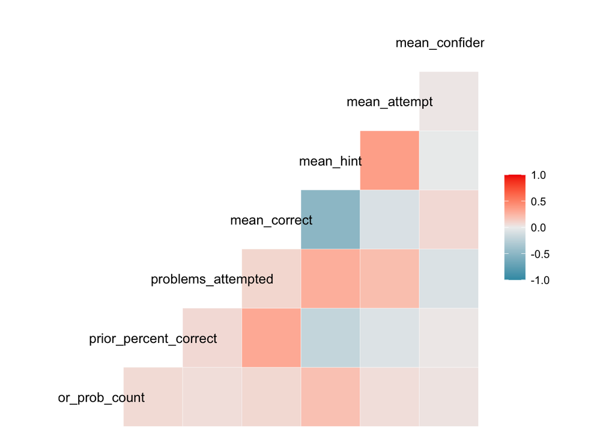

```r
#ggpairs() draws a correlation plot between all the columns you identify by number (second option, you don't need the first column as it is the student ID) and progress = FALSE stops a progress bar appearing as it renders your plot

ggcorr(D1[,-1], method = c("everything", "pearson"))
```

```r
#ggcorr() doesn't have an explicit option to choose variables so we need to use matrix notation to drop the id variable. We then need to choose a "method" which determines how to treat missing values (here we choose to keep everything, and then which kind of correlation calculation to use, here we are using Pearson correlation, the other options are "kendall" or "spearman")

#Study your correlogram images and save them, you will need them later. Take note of what is strongly related to the outcome variable of interest, mean_correct.
```

## Create a new data frame with the mean_correct variable removed, we want to keep that variable intact. The other variables will be included in our PCA.

```r
D2 <- D1 %>% select(-mean_correct,-id)
head(D2)
```

```
## # A tibble: 6 x 6
##   prior_prob_count prior_percent_c… problems_attemp… mean_hint mean_attempt
##              <dbl>            <dbl>            <dbl>     <dbl>        <dbl>
## 1              650            0.723                4     0             1
## 2             1159            0.801               22     2.23          1.23
## 3             1239            0.657               11     1.36          1.73
## 4             1246            0.730               16     0.562         1.19
## 5             1299            0.568                6     2.17          2
## 6             1415            0.685               11     2             1.27
## # … with 1 more variable: mean_confidence <dbl>
```

## Now run the PCA on the new data frame

```r
pca <- prcomp(D2, scale. = TRUE)
```

## Although princomp does not generate the eigenvalues directly for us, we can print a list of the standard deviation of the variance accounted for by each component.

```r
pca$sdev
```

```
## [1] 1.2825140 1.0543565 1.0245688 0.9621486 0.8556715 0.7320146
```

```r
#To convert this into variance accounted for we can square it, these numbers are proportional to the eigenvalue

pca$sdev^2
```

```
## [1] 1.6448423 1.1116675 1.0497412 0.9257299 0.7321737 0.5358454
```

```r
#A summary of our pca will give us the proportion of variance accounted for by each component

summary(pca)
```

```
## Importance of components:
##                           PC1    PC2    PC3    PC4    PC5     PC6
## Standard deviation     1.2825 1.0544 1.0246 0.9621 0.8557 0.73201
## Proportion of Variance 0.2741 0.1853 0.1750 0.1543 0.1220 0.08931
## Cumulative Proportion  0.2741 0.4594 0.6344 0.7887 0.9107 1.00000
```

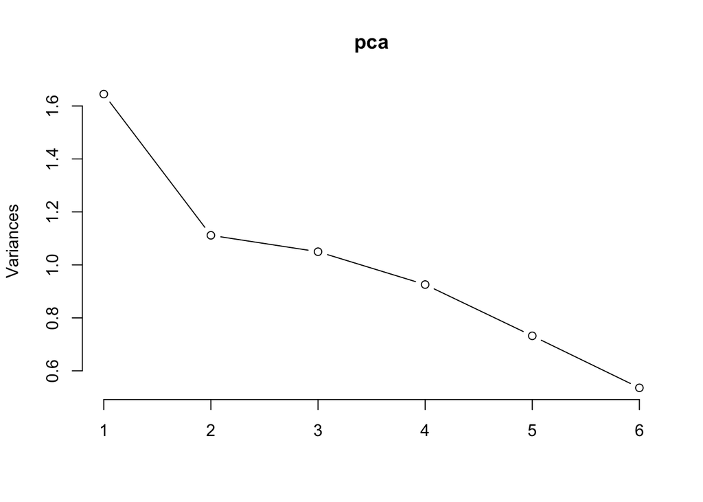

```r
#We can look at this to get an idea of which components we should keep and which we should drop

plot(pca, type = "lines")
```

## Decide which components you would drop and remove them from your data set.

`answer`

Usually there are several ways to determine how many variables to keep.

1. Based on the cumulative proportion of variance, we typically keep the components which together could explain at least 80 percent of the variance. In this case, we should keep the first five components.
2. Based on the variance itself, we typically only keep the components which has the variance at least bigger than 1. In this case we should keep the first three components.
3. In the end, we should also think about how good interpretation ability each the principal component has. Each principal component is a linear combination of the original variables, which we should check whether each components’ result makes sense.

In this study, I will only keep the first 5 principal components.

## Part II

```r
#Now, create a data frame of the transformed data from your pca.

D3 <- as.data.frame(as.matrix(D2) %*% pca$rotation[,1:5])


#Attach the variable "mean_correct" from your original data frame to D3.
D3$mean_correct <- D1$mean_correct
head(D3)
```

```
##         PC1      PC2       PC3       PC4        PC5 mean_correct
## 1 -171.4452 299.6084 -259.5697 -446.3054  -6.237155    1.0000000
## 2 -313.6862 538.2918 -457.1695 -791.9074 -20.552801    0.4545455
## 3 -329.2465 571.4115 -493.2728 -850.3226 -14.232990    0.6363636
## 4 -332.5358 576.4079 -494.1480 -853.6352 -17.512482    0.7500000
## 5 -343.2636 597.1198 -519.1477 -893.3714 -11.592997    0.3333333
## 6 -375.2153 652.0366 -563.9351 -971.8817 -15.886574    0.5454545
```

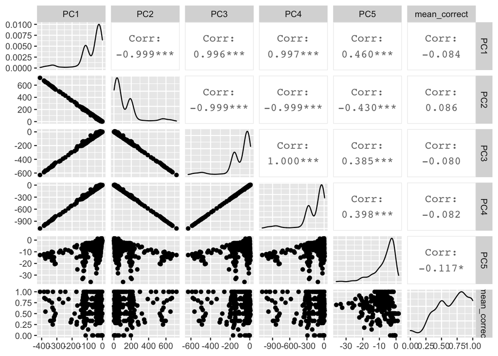

```r
#Now re-run your correlation plots between the transformed data and mean_correct. If you had dropped some components would you have lost important information about mean_correct?

ggpairs(D3, progress = FALSE)
```

```r
round(pca$rotation[,1:5],2)
```

```
##                         PC1   PC2   PC3   PC4   PC5
## prior_prob_count      -0.26  0.46 -0.40 -0.69 -0.01
## prior_percent_correct  0.17  0.82  0.09  0.26  0.30
## problems_attempted    -0.46  0.32  0.36  0.32 -0.59
## mean_hint             -0.63 -0.13 -0.08 -0.11 -0.10
## mean_attempt          -0.54 -0.09 -0.05  0.31  0.70
## mean_confidence        0.04  0.03 -0.83  0.49 -0.25
```

## Now print out the loadings for the components you generated:

```r
pca$rotation
```

```
##                               PC1         PC2         PC3        PC4
## prior_prob_count      -0.26034140  0.45818753 -0.40090679 -0.6897642
## prior_percent_correct  0.16840319  0.81617867  0.09267306  0.2640040
## problems_attempted    -0.45568733  0.31685183  0.36387724  0.3168141
## mean_hint             -0.63337594 -0.12501620 -0.08008842 -0.1122586
## mean_attempt          -0.54200011 -0.08510858 -0.04585364  0.3108682
## mean_confidence        0.03581325  0.02547483 -0.83051917  0.4948890
##                                PC5         PC6
## prior_prob_count      -0.007142834 -0.29280482
## prior_percent_correct  0.298843852  0.37134715
## problems_attempted    -0.592336569 -0.32911025
## mean_hint             -0.102302115  0.74412634
## mean_attempt           0.697232132 -0.33781385
## mean_confidence       -0.251357022 -0.01452143
```

```r
#Examine the eigenvectors, notice that they are a little difficult to interpret. It is much easier to make sense of them if we make them proportional within each component

loadings <- abs(pca$rotation) #abs() will make all eigenvectors positive
loadings
```

```
##                              PC1        PC2        PC3       PC4         PC5
## prior_prob_count      0.26034140 0.45818753 0.40090679 0.6897642 0.007142834
## prior_percent_correct 0.16840319 0.81617867 0.09267306 0.2640040 0.298843852
## problems_attempted    0.45568733 0.31685183 0.36387724 0.3168141 0.592336569
## mean_hint             0.63337594 0.12501620 0.08008842 0.1122586 0.102302115
## mean_attempt          0.54200011 0.08510858 0.04585364 0.3108682 0.697232132
## mean_confidence       0.03581325 0.02547483 0.83051917 0.4948890 0.251357022
##                              PC6
## prior_prob_count      0.29280482
## prior_percent_correct 0.37134715
## problems_attempted    0.32911025
## mean_hint             0.74412634
## mean_attempt          0.33781385
## mean_confidence       0.01452143
```

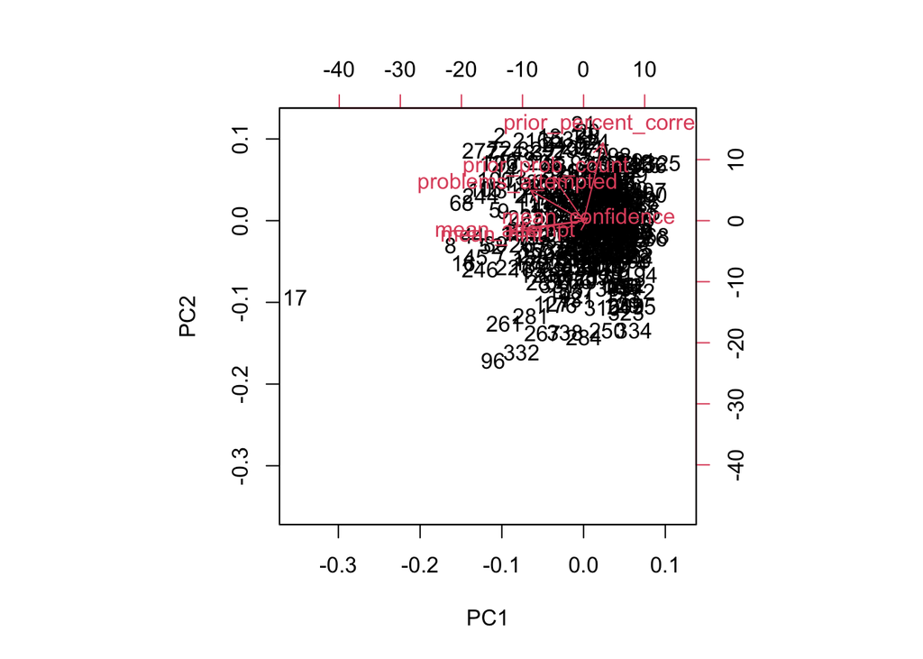

```r
#Now examine your components and try to come up with substantive descriptions of what some might represent?

#You can generate a biplot to help you, though these can be a bit confusing. They plot the transformed data by the first two components. Therefore, the axes represent the direction of maximum variance accounted for. Then mapped onto this point cloud are the original directions of the variables, depicted as red arrows. It is supposed to provide a visualization of which variables "go together". Variables that possibly represent the same underlying construct point in the same direction.

biplot(pca)
```

For the first principal component: it mainly related to the attempts at problems in the current session. In which, mean hint and mean attempt have biggest contribution.

For the second principal component: it mainly related to prior experience. In which, prior prob count and prior percent correct have biggest contribution.

For the third principal component: it mainly related to the mean confidence.

For the fourth principal component: it mainly related to the prior prob count and mean confidence.

For the fifth principal component: it mainly related to the mean attempt.

For the sixth principal component: it mainly related to mean hint.

# Part III

Also in this repository is a data set collected from TC students (tc-program-combos.csv) that shows how many students thought that a TC program was related to another TC program. Students were shown three program names at a time and were asked which two of the three were most similar. Use PCA to look for components that represent related programs. Explain why you think there are relationships between these programs.

`answer`

First, I transfer the original data into the correlation matrix. In the original data, the max value is 14, which represents the case when correlation between two course is 1. Whereas the min value is 0, which represents the case when correlation between two course is 0. All the other value will be transferred into a correlation-type value range from 0 to 1.

```r
data <- read_csv("tc-program-combos.csv")
head(data)
```

```
## # A tibble: 6 x 68
##   program Adult.Education Anthropology Social.Studies Physiology
##   <chr>             <dbl>        <dbl>          <dbl>      <dbl>
## 1 Adult.…               0            0              0          0
## 2 Anthro…               0            0              3          1
## 3 Social…               1            2              0          1
## 4 Physio…               0            2              0          0
## 5 Behavi…               1            1              1          4
## 6 Lingui…               1            4              1          0
## # … with 63 more variables: Behavior.Analysis <dbl>, Linguistics <dbl>,
## #   Art.Education <dbl>, Teaching.English <dbl>, Arts.Administration <dbl>,
## #   Bilingual.Bicultural.Education <dbl>, Clinical.Psychology <dbl>,
## #   Cognitive.Science <dbl>, College.Advising <dbl>,
## #   Communication.Sciences.and.Disorders <dbl>,
## #   Cooperation.and.Conflict.Resolution <dbl>, Creative.Technologies <dbl>,
## #   Curriculum.and.Teaching <dbl>, Dance.Education <dbl>,
## #   Deaf.and.Hard.of.Hearing <dbl>,
## #   Design.and.Development.of.Digital.Games <dbl>,
## #   Developmental.Psychology <dbl>, Diabetes.Education <dbl>,
## #   Early.Childhood.Education <dbl>, Early.Childhood.Special.Education <dbl>,
## #   Economics.and.Education <dbl>, Education.Technology <dbl>,
## #   Education.Leadership <dbl>, Education.Policy <dbl>,
## #   Inclusive.Education <dbl>, English.Education <dbl>,
## #   Change.Leadership <dbl>, Nursing <dbl>, Gifted.Education <dbl>,
## #   Health.Education <dbl>, Higher.and.Postsecondary.Education <dbl>,
## #   History <dbl>, Instructional.Technology.and.Media <dbl>,
## #   Intellectual.Disability.Autism <dbl>,
## #   International.and.Comparative.Education <dbl>, Kinesiology <dbl>,
## #   Learning.Analytics <dbl>, Literacy <dbl>, Mathematics <dbl>,
## #   Measurement..Evaluation.and.Statistics <dbl>,
## #   Motor.Learning.and.Control <dbl>, Movement.Science <dbl>, Music <dbl>,
## #   Neuroscience <dbl>, Nutrition <dbl>, Leadership <dbl>, Philosophy <dbl>,
## #   Physical.Education <dbl>, Politics <dbl>, Private.School.Leadership <dbl>,
## #   Psychological.Counseling <dbl>, Psychology <dbl>, Reading <dbl>,
## #   School.Psychology <dbl>, Science.Education <dbl>,
## #   Sexuality..Women.and.Gender.in.Psychology <dbl>,
## #   Social.Organizational.Psychology <dbl>, Sociology <dbl>,
## #   Spirituality.Mind.Body <dbl>, School.Principals <dbl>,
## #   Urban.Education <dbl>, Counseling.Psychology <dbl>,
## #   Communication.Media.and.Learning.Technologies <dbl>
```

```r
rating <- as.matrix(data[1:nrow(data)-1,2:ncol(data)])
rating_cor <- rating / max(rating)
pca <- prcomp(rating_cor)
summary(pca)
```

```
## Importance of components:
##                           PC1     PC2     PC3     PC4     PC5     PC6     PC7
## Standard deviation     0.2214 0.20684 0.18789 0.16584 0.14314 0.13835 0.13370
## Proportion of Variance 0.1030 0.08988 0.07416 0.05778 0.04304 0.04021 0.03755
## Cumulative Proportion  0.1030 0.19285 0.26701 0.32479 0.36783 0.40804 0.44559
##                            PC8     PC9    PC10    PC11    PC12    PC13    PC14
## Standard deviation     0.13081 0.12460 0.11576 0.11328 0.10929 0.10773 0.10579
## Proportion of Variance 0.03594 0.03261 0.02815 0.02696 0.02509 0.02438 0.02351
## Cumulative Proportion  0.48154 0.51415 0.54230 0.56926 0.59435 0.61874 0.64225
##                           PC15    PC16    PC17    PC18    PC19    PC20    PC21
## Standard deviation     0.10374 0.10041 0.09801 0.09702 0.09216 0.08967 0.08906
## Proportion of Variance 0.02261 0.02118 0.02018 0.01977 0.01784 0.01689 0.01666
## Cumulative Proportion  0.66485 0.68603 0.70621 0.72599 0.74383 0.76072 0.77738
##                           PC22    PC23    PC24    PC25    PC26    PC27    PC28
## Standard deviation     0.08525 0.08336 0.08256 0.08081 0.07881 0.07530 0.07345
## Proportion of Variance 0.01527 0.01460 0.01432 0.01372 0.01305 0.01191 0.01133
## Cumulative Proportion  0.79265 0.80725 0.82157 0.83529 0.84834 0.86025 0.87159
##                           PC29    PC30    PC31    PC32    PC33    PC34    PC35
## Standard deviation     0.07128 0.06950 0.06687 0.06289 0.06146 0.05872 0.05781
## Proportion of Variance 0.01067 0.01015 0.00939 0.00831 0.00794 0.00724 0.00702
## Cumulative Proportion  0.88226 0.89241 0.90180 0.91011 0.91805 0.92529 0.93231
##                           PC36    PC37    PC38    PC39    PC40    PC41    PC42
## Standard deviation     0.05500 0.05310 0.05045 0.05031 0.04786 0.04581 0.04465
## Proportion of Variance 0.00636 0.00592 0.00535 0.00532 0.00481 0.00441 0.00419
## Cumulative Proportion  0.93867 0.94459 0.94994 0.95525 0.96006 0.96447 0.96866
##                           PC43    PC44    PC45    PC46    PC47    PC48    PC49
## Standard deviation     0.04158 0.04011 0.03818 0.03620 0.03399 0.03329 0.02967
## Proportion of Variance 0.00363 0.00338 0.00306 0.00275 0.00243 0.00233 0.00185
## Cumulative Proportion  0.97229 0.97567 0.97873 0.98149 0.98391 0.98624 0.98809
##                           PC50    PC51    PC52    PC53    PC54   PC55    PC56
## Standard deviation     0.02885 0.02741 0.02639 0.02431 0.02352 0.0218 0.02096
## Proportion of Variance 0.00175 0.00158 0.00146 0.00124 0.00116 0.0010 0.00092
## Cumulative Proportion  0.98984 0.99142 0.99288 0.99412 0.99528 0.9963 0.99721
##                           PC57    PC58    PC59    PC60    PC61    PC62     PC63
## Standard deviation     0.01886 0.01586 0.01372 0.01314 0.01167 0.01133 0.008097
## Proportion of Variance 0.00075 0.00053 0.00040 0.00036 0.00029 0.00027 0.000140
## Cumulative Proportion  0.99795 0.99848 0.99888 0.99924 0.99952 0.99979 0.999930
##                            PC64     PC65     PC66      PC67
## Standard deviation     0.004439 0.002896 0.001873 0.0009744
## Proportion of Variance 0.000040 0.000020 0.000010 0.0000000
## Cumulative Proportion  0.999970 0.999990 1.000000 1.0000000
```

I choose to keep the first 25 components. Here is the interpreation of the first three components.

For the first component, the main contribution came from change.leadership, economics.and.education, school.principals. These are highly related to the education (educational leadership).

For the second component, the main contribution came from creative.technologies and design.and.development.of.digital.games. These are highly related to the technologies.

For the third component: the main contribution came from neurosicence, psychology, clinical psychology. These are highly related to psychology.

```r
rotate <- abs(round(pca$rotation[,1:3],2))
sort(rotate[,1],decreasing = T)[1:10]
```

```
##                   Change.Leadership             Economics.and.Education
##                                0.29                                0.25
##                   School.Principals                 Arts.Administration
##                                0.23                                0.22
##                             History                            Politics
##                                0.22                                0.22
## Cooperation.and.Conflict.Resolution                    Education.Policy
##                                0.19                                0.19
##    Social.Organizational.Psychology                     Urban.Education
##                                0.19                                0.19
```

```r
sort(rotate[,2],decreasing = T)[1:10]
```

```
##                         Creative.Technologies
##                                          0.65
##       Design.and.Development.of.Digital.Games
##                                          0.31
##                                   Linguistics
##                                          0.25
##                                       Nursing
##                                          0.18
##                            Learning.Analytics
##                                          0.17
##                             Cognitive.Science
##                                          0.16
##                              Health.Education
##                                          0.16
##                                    Physiology
##                                          0.15
##                            Diabetes.Education
##                                          0.15
## Communication.Media.and.Learning.Technologies
##                                          0.15
```

```r
sort(rotate[,3],decreasing = T)[1:10]
```

```
##          Neuroscience            Psychology   Clinical.Psychology
##                  0.29                  0.27                  0.25
##     Cognitive.Science            Physiology Creative.Technologies
##                  0.23                  0.22                  0.22
##     Behavior.Analysis               Nursing           Kinesiology
##                  0.21                  0.20                  0.19
## Counseling.Psychology
##                  0.19
```